# Curs d’introducció a R

Classe 7: Gràfics en ggplot2

Eudald Correig i Fraga

31 de juliol de 2025

## Gràfics

- Hem vist al llarg del curs que dibuixar és primordial
- R té moltíssimes maneres de dibuixar, i a més fa dibuixos a nivell de publicació amb relativament poc esforç (““““relativament”“““)
- Hi ha moltes llibreries, però la més utilitzada és “ggplot2”
- N’hi ha d’altres d’interessants: plotly, ggvis, ggforce, etc.
- Si algú està molt interessat, en python hi ha eines més potents: matplotlib, seaborn, etc.

## ggplot2

- El nom prové de Grammar of Graphics, un llibre teòric sobre com es fan els gràfics digitals.
- Tradueix teòricament estètica a píxels.
- Si algú està molt interssat, [aquí](http://www.springer.com/us/book/9780387245447) el pot trobar.
- Un exemple:

```r
liver <- read_csv('data/indian_liver_patient.csv') |>
  rename(Malaltia = Dataset) |>
  mutate(Malaltia = factor(Malaltia, levels = 1:2, labels = c("Sa", "Malalt")))
```

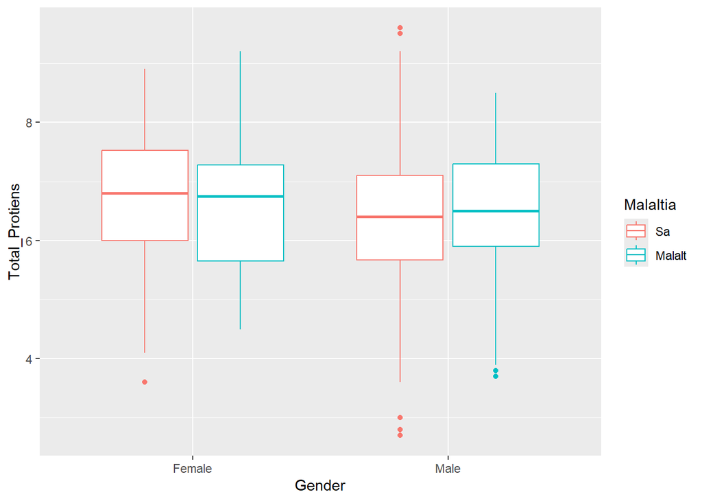

```r
library(ggplot2)
liver |>
  ggplot(aes(x = Gender, y = Total_Protiens, colour = Malaltia)) +
  geom_boxplot()
```

Com funciona:

- La funció ggplot() crea el gràfic i sempre necessita dos paràmetres:
  1. Les dades amb les que fer el gràfic; les posem al principi
  2. Els estètics (aesthetics en anglès, d’aquí el nom): aquí hi posem quina variable volem a l’eix x i y, i si volem colors o formes diferents.
- Per acabar, li diem quin tipus de gràfic volem, en aquest cas un diagrama de caixes (boxplot)

Ho mirem en el plot:

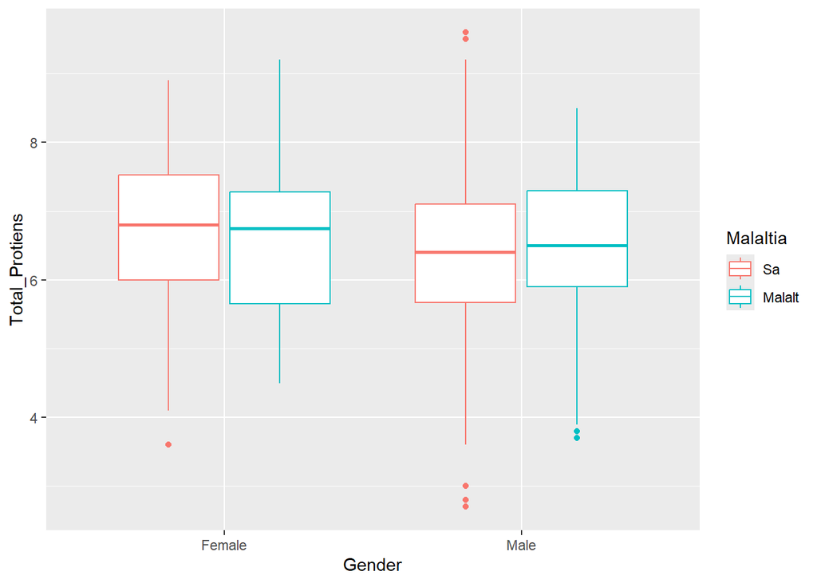

```r
ggplot(liver, # liver és el nom del dataframe
       aes(x = Gender, # Variable en l'eix x
           y = Total_Protiens, # Variable en l'eix y
           colour = Malaltia # Color: alerta, perquè el color crea grups!
           )) + # fixeu-vos en el signe "+" per afegir més comandes a la instrucció
  geom_boxplot() # geom_alguna_cosa() crea el tipus de plot que vulguem, en aquest cas un boxplot. Per saber els tipus de plots que hi ha podem anar a https://ggplot2.tidyverse.org/reference/
```

Un altre exemple:

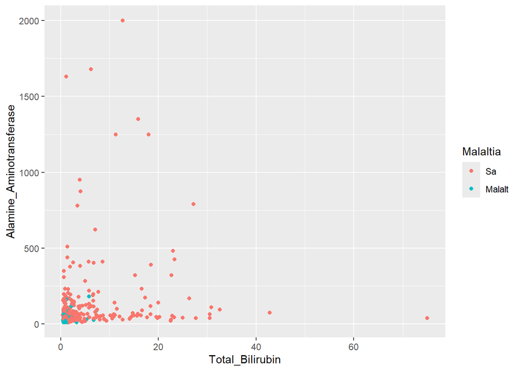

```r
liver |>
  ggplot(aes(Total_Bilirubin, Alamine_Aminotransferase, colour = Malaltia)) +
  geom_point()
```

Veiem que necessitem una escala logarítmica, ho podem fer en el plot mateix:

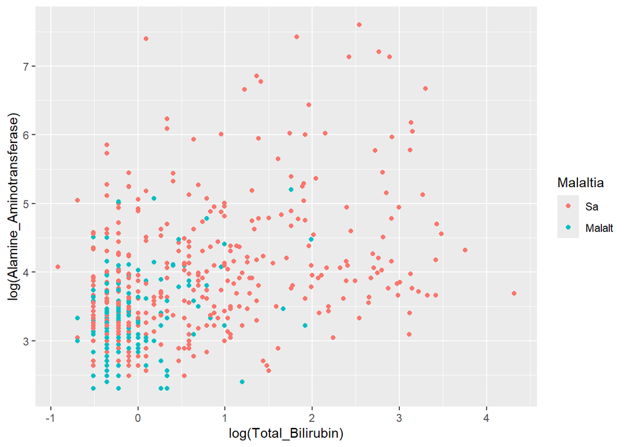

```r
liver |>
  ggplot(aes(log(Total_Bilirubin), log(Alamine_Aminotransferase),
                  colour = Malaltia)) +
  geom_point()
```

Potser ens agrada més amb el fons blanc:

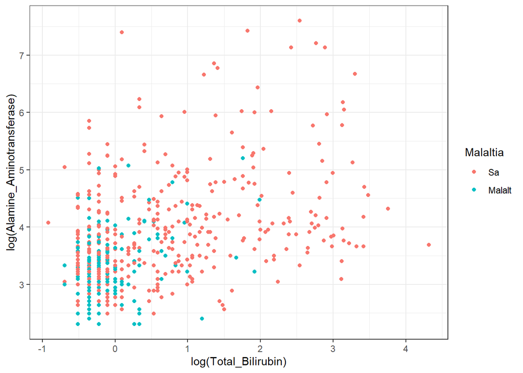

```r
liver |>
  ggplot(aes(log(Total_Bilirubin), log(Alamine_Aminotransferase), colour = Malaltia)) +
  geom_point() +
  theme_bw()
```

En lloc dels boxplots, a vegades volem els violin plots:

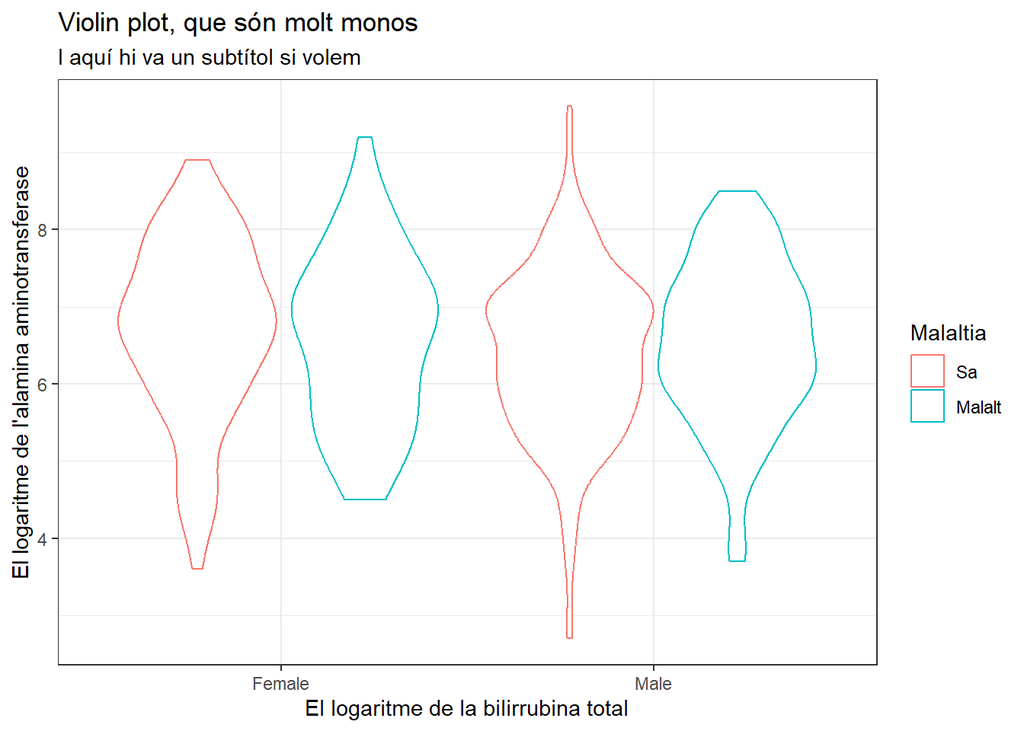

```r
liver |>
  ggplot(aes(x = Gender, y = Total_Protiens, colour = Malaltia)) +
    geom_violin() +
    theme_bw() +
    labs(title = "Violin plot, que són molt monos",
         subtitle = "I aquí hi va un subtítol si volem") +
    xlab("El logaritme de la bilirrubina total") +
    ylab("El logaritme de l'alamina aminotransferase")
```

Vaja, sembla que no estan plens de color, hem de fer servir “fill”:

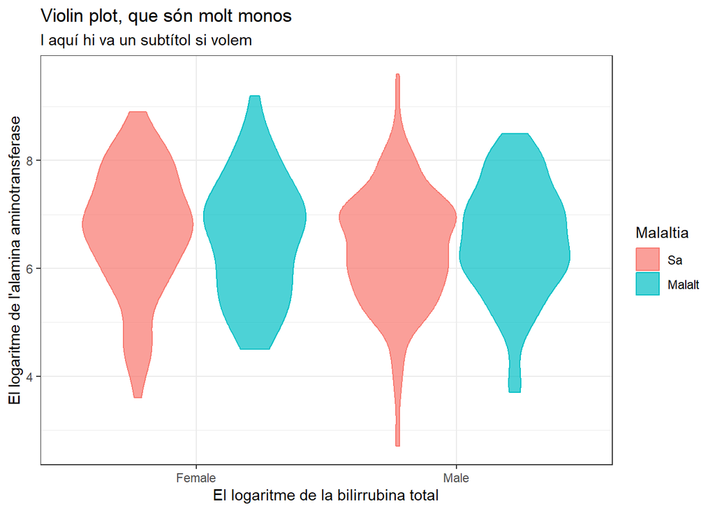

```r
liver |>
  ggplot(aes(x = Gender, y = Total_Protiens,
                  colour = Malaltia, fill = Malaltia)) +
    geom_violin(alpha = 0.7) + # aquesta alpha fa que el color no sigui sòlid
    theme_bw() +
    labs(title = "Violin plot, que són molt monos",
         subtitle = "I aquí hi va un subtítol si volem") +
    xlab("El logaritme de la bilirrubina total") +
    ylab("El logaritme de l'alamina aminotransferase")
```

A partir d’aquí hi ha moltíssimes maneres de personalitzar un diagrama:

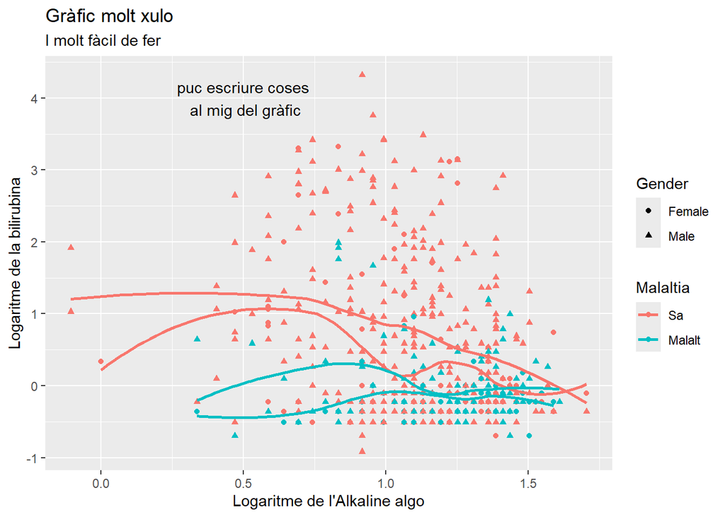

```r
liver |>
  ggplot(aes(x = log(Albumin), y = log(Total_Bilirubin),
                  colour = Malaltia, shape = Gender)) +
    geom_point(size=1.5) +
    labs(title = "Gràfic molt xulo",
         subtitle = "I molt fàcil de fer") +
    xlab("Logaritme de l'Alkaline algo") +
    ylab("Logaritme de la bilirubina") +
    geom_smooth(method = "loess", se = FALSE) +
    theme_gray() +
    annotate("text", x = 0.5, y= 4, label = "puc escriure coses\n al mig del gràfic")
```

```r
liver <- liver |>
  mutate(across(c(Total_Bilirubin, Direct_Bilirubin, Alkaline_Phosphotase, Alamine_Aminotransferase, Aspartate_Aminotransferase)))
```

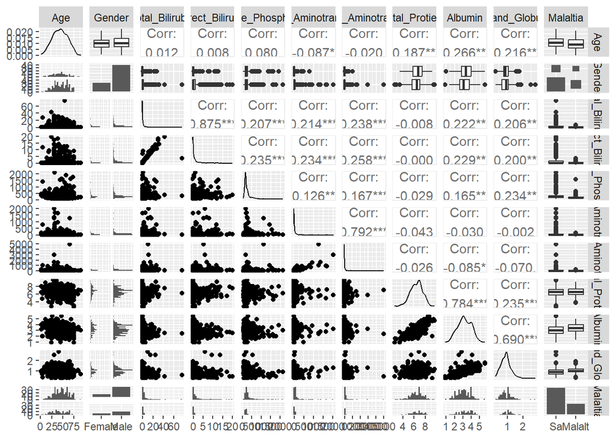

```r
GGally::ggpairs(liver)
```

# Gràfics en 3D

A vegades també ens poden interessar els gràfics en 3D, tot i que per publicar no solen ser gaire acceptats (ja que quan els imprimim no es veuen gaire bé). De totes maneres, en R són molt senzills de fer amb la llibreria plotly. Anem a veure un exemple:

```r
require(plotly)
plot_ly(liver,
        x = ~Total_Bilirubin,
        y = ~Alkaline_Phosphotase,
        z = ~Total_Protiens,
        color = ~Malaltia,
        colors = c('#BF382A', '#0C4B8E'))
```

[interactive chart not shown]

Fixeu-vos que tenim un petit “widget”, on podem fer zoom, rotar i fins i tot fer desaparèixer alguna de les opcions, i tot amb una sola línia de codi!